# Research log

Dennis Scheper

11-9-2020

# Week 1 - original dataset

Date: 11 September, 2020 (week 1)

## Dataset and Attributes Information

Of these five criteria points, 101.000 encounters fulfilled all specifications. After some considerations with removing encounters based on incomplete (weight and medical specialty) or biased data (discharge to a hospice or death), 69.984 encounters remained in the final dataset.

## Research Question

Is it possible, using machine learning techniques, to predict whether a patient’s time in hospital is linked to the results of an HbA1c measurement?

# Week 2 - EDA (Exploratory Data Analysis)

## Date: 14 September, 2020

This section will perform an exploratory data analysis (EDA) on the dataset described above. With an EDA, we can explore our dataset and determine if any correlations exist between attributes and undermine any missing values. If any exist, we deal with them accordingly, looking to repair these values or remove them entirely. Additionally, we will look at variations between and in attributes for determining which ones are of most importance and interest to our research goals.

First, we load in our used packages, mostly used for visualization of data, and the data itself. Besides that, we also load in a codebook, which contains, i.e., a description for every attribute for the initial dataset. The codebook was not retrieved from any outside source but was constructed on the interpretation of the data.

To get a better picture of our dataset’s distribution, we called upon the function glimpse(). We notice that the data contains 50 columns/ attributes. Additionally, a summary() function gives an outline of every attribute, showing each level with a count of its valuation.

```
## Rows: 101,766
## Columns: 50
## $ encounter_id             <int> 2278392, 149190, 64410, 500364, 16680, 357...
## $ patient_nbr              <int> 8222157, 55629189, 86047875, 82442376, 425...
## $ race                     <fct> Caucasian, Caucasian, AfricanAmerican, Cau...
## $ gender                   <fct> Female, Female, Female, Male, Male, Male, ...
## $ age                      <fct> [0-10), [10-20), [20-30), [30-40), [40-50)...
## $ weight                   <fct> ?, ?, ?, ?, ?, ?, ?, ?, ?, ?, ?, ?, ?, ?, ...
## $ admission_type_id        <int> 6, 1, 1, 1, 1, 2, 3, 1, 2, 3, 1, 2, 1, 1, ...
## $ discharge_disposition_id <int> 25, 1, 1, 1, 1, 1, 1, 1, 1, 3, 1, 1, 3, 6,...
## $ admission_source_id      <int> 1, 7, 7, 7, 7, 2, 2, 7, 4, 4, 7, 4, 7, 7, ...
## $ time_in_hospital         <int> 1, 3, 2, 2, 1, 3, 4, 5, 13, 12, 9, 7, 7, 1...
## $ payer_code               <fct> ?, ?, ?, ?, ?, ?, ?, ?, ?, ?, ?, ?, ?, ?, ...
## $ medical_specialty        <fct> Pediatrics-Endocrinology, ?, ?, ?, ?, ?, ?...
## $ num_lab_procedures       <int> 41, 59, 11, 44, 51, 31, 70, 73, 68, 33, 47...
```

[output cut: 37 more lines]

```
##   encounter_id        patient_nbr                     race
##  Min.   :    12522   Min.   :      135   ?              : 2273
##  1st Qu.: 84961194   1st Qu.: 23413221   AfricanAmerican:19210
##  Median :152388987   Median : 45505143   Asian          :  641
##  Mean   :165201646   Mean   : 54330401   Caucasian      :76099
##  3rd Qu.:230270888   3rd Qu.: 87545950   Hispanic       : 2037
##  Max.   :443867222   Max.   :189502619   Other          : 1506
##
##              gender           age              weight      admission_type_id
##  Female         :54708   [70-80):26068   ?        :98569   Min.   :1.000
##  Male           :47055   [60-70):22483   [75-100) : 1336   1st Qu.:1.000
##  Unknown/Invalid:    3   [50-60):17256   [50-75)  :  897   Median :1.000
##                          [80-90):17197   [100-125):  625   Mean   :2.024
##                          [40-50): 9685   [125-150):  145   3rd Qu.:3.000
##                          [30-40): 3775   [25-50)  :   97   Max.   :8.000
##                          (Other): 5302   (Other)  :   97
##  discharge_disposition_id admission_source_id time_in_hospital   payer_code
##  Min.   : 1.000           Min.   : 1.000      Min.   : 1.000   ?      :40256
##  1st Qu.: 1.000           1st Qu.: 1.000      1st Qu.: 2.000   MC     :32439
##  Median : 1.000           Median : 7.000      Median : 4.000   HM     : 6274
##  Mean   : 3.716           Mean   : 5.754      Mean   : 4.396   SP     : 5007
##  3rd Qu.: 4.000           3rd Qu.: 7.000      3rd Qu.: 6.000   BC     : 4655
##  Max.   :28.000           Max.   :25.000      Max.   :14.000   MD     : 3532
##                                                                (Other): 9603
##               medical_specialty num_lab_procedures num_procedures
##  ?                     :49949   Min.   :  1.0      Min.   :0.00
##  InternalMedicine      :14635   1st Qu.: 31.0      1st Qu.:0.00
##  Emergency/Trauma      : 7565   Median : 44.0      Median :1.00
##  Family/GeneralPractice: 7440   Mean   : 43.1      Mean   :1.34
##  Cardiology            : 5352   3rd Qu.: 57.0      3rd Qu.:2.00
##  Surgery-General       : 3099   Max.   :132.0      Max.   :6.00
##  (Other)               :13726
##  num_medications number_outpatient number_emergency  number_inpatient
##  Min.   : 1.00   Min.   : 0.0000   Min.   : 0.0000   Min.   : 0.0000
##  1st Qu.:10.00   1st Qu.: 0.0000   1st Qu.: 0.0000   1st Qu.: 0.0000
##  Median :15.00   Median : 0.0000   Median : 0.0000   Median : 0.0000
##  Mean   :16.02   Mean   : 0.3694   Mean   : 0.1978   Mean   : 0.6356
##  3rd Qu.:20.00   3rd Qu.: 0.0000   3rd Qu.: 0.0000   3rd Qu.: 1.0000
##  Max.   :81.00   Max.   :42.0000   Max.   :76.0000   Max.   :21.0000
##
```

[output cut: 41 more lines]

```
##  No    :101753       No    :101765            No    :101764
##  Steady:    13       Steady:     1            Steady:     2
##
##
##
##
##
##  metformin.pioglitazone change     diabetesMed readmitted
##  No    :101765          Ch:47011   No :23403   <30:11357
##  Steady:     1          No:54755   Yes:78363   >30:35545
##                                                NO :54864
##
##
##
##
```

## Missing values

As we see in the result determined by the glimpse() function, the columns race, weight, payer_code, gender, diag_3, and medical specialty have some or significant amounts of missing values. To get a better picture, we will zoom in on these attributes and determine the amount and the percentage of missing values.

|  | Missing.Values | Missing.Values.Percentage |
| --- | --- | --- |
| race | 2273 | 2.23 |
| weight | 98569 | 96.86 |
| payer_code | 40256 | 39.56 |
| medical_specialty | 49949 | 49.08 |
| gender | 3 | 0.00 |
| diag_3 | 1423 | 1.40 |

As we notice in table 1, attribute weight is almost entirely made-up of missing values. For that reason, it is a candidate for removal. The same can be said for payer_code and medical_specialty, where 39.56% and 49.08% of values are missing, respectively. Payer_code has no significant value to our research goals and questions; therefore, it can be removed. Medical_specialty can be of value as it contains a range of useful information. Missing values can be set to ‘Missing’ or reevaluated based on other valuations; doing this is not without risk, as it is almost half of the attributes’ values. Deleting all missing values is not doable as it removes half of all records! Setting it to ‘Missing’ seems to be the most logical option. Attributes race and diag_3 seem to have little amounts of missing data, but removing these values can alter our outcomes; therefore, we will use the same approach as to medical_specialty. Gender only has three missing values. Considering the amount does not account to even one percent, removal does not seem to harm, and gender is, in most cases, considered binary data.

(Date: 18-20 September, 2020)

Before we start analyzing our dataset, it is crucial to check on duplicates as our dataset contains multiple inpatient visits for some patients. These observations cannot be statistically independent and would create noise. We thus declare that only one encounter per patient is optimal.

| Initial.number.of.records | Number.of.Duplicates | Difference.in.percent |
| --- | --- | --- |
| 101766 | 16773 | -16.48 |

## Categorial attributes

In this section, we take a look at variations in and between attributes. The attribute gender consists of three values (‘female,’ ‘male,’ and ‘missing/unknown’). Since observe and use this attribute, it is essential to remove the abundant value.

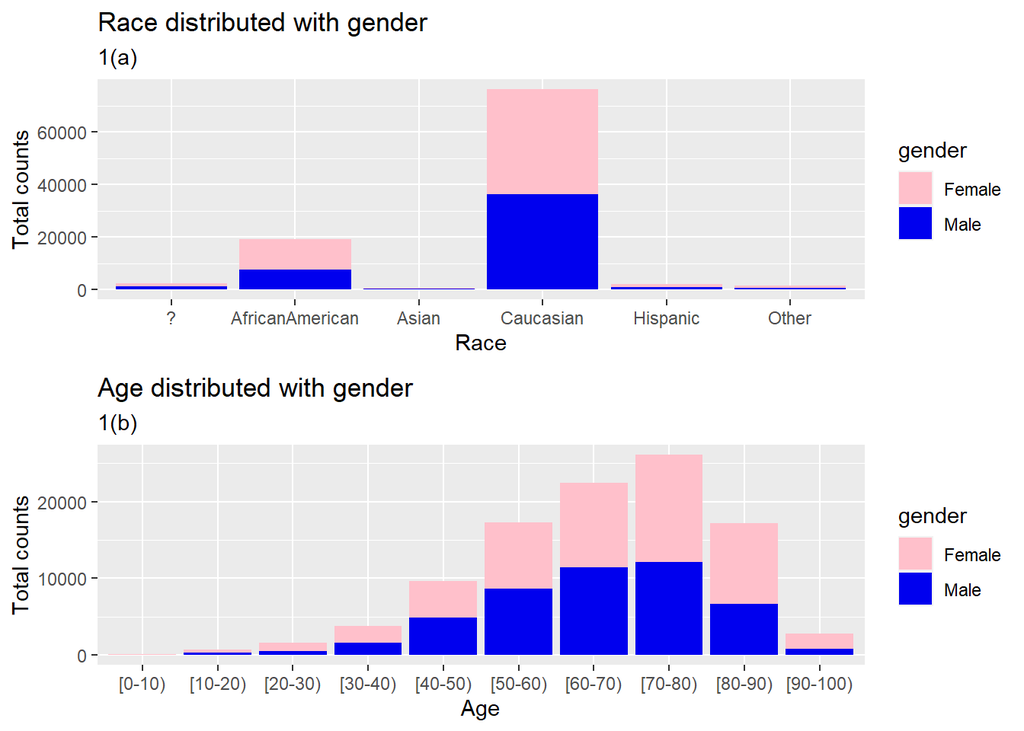

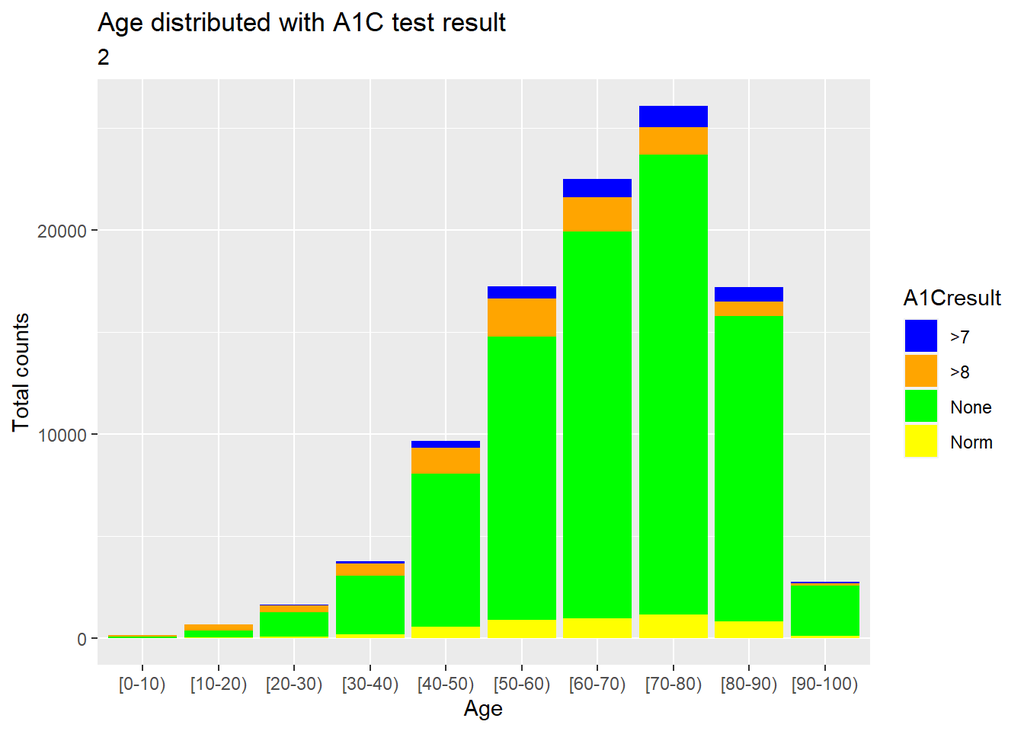

Looking at figure 1a, we notice that most patients are from the Caucasian race with almost equivalent male and female ratios. We expect a rise in the number of diabetes patients when looking at older population groups. Figure 1b shows this exact prediction; the data is negatively skewed and increases in numbers per older age group. We observe the same results in figure 2, where an increase in A1C test is shown when comparing older population groups. Additionally, the figure gives an essential insight for many patients - in most cases, the test was not conducted and shows that strategies surrounding testing diabetes are not normalized in hospital protocols.

This graph does not, however, make a distinction between non-ICU and ICU patients. The authors of the original dataset analyses stated that ICU departments’ protocols have a stricter policy surrounding testing for diabetes. When comparing non-ICU and ICU patient records, we need to construct a new attribute called ‘icu_or_non,’ comprising data from attributes admission_type_id, admission_source_id, and discharge_disposition_id. We distinguish between non-ICU and ICU patients.

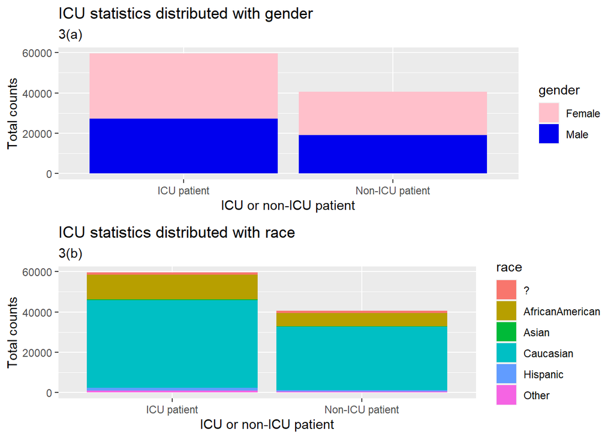

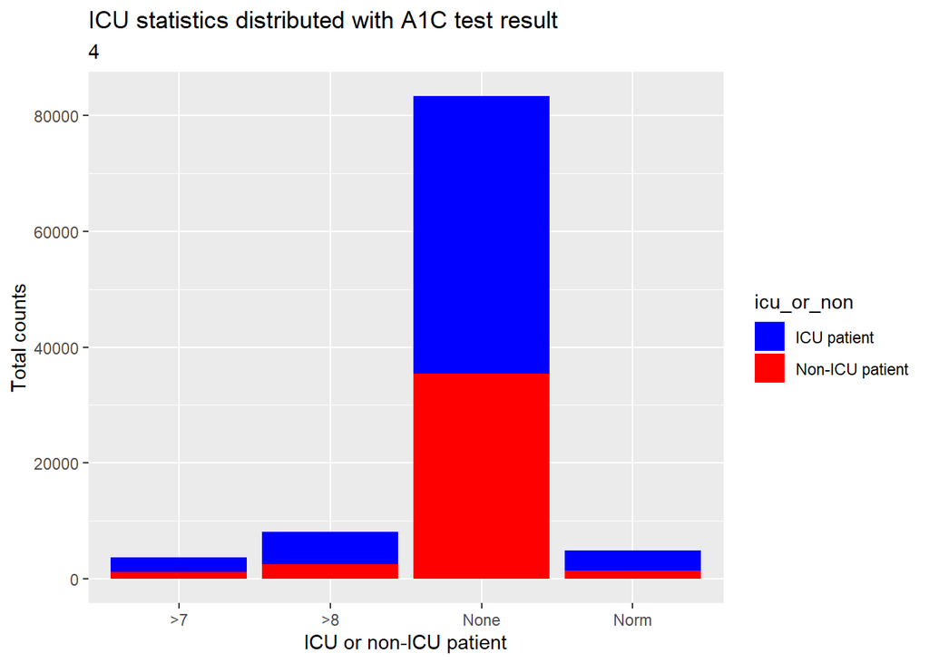

We observe the result from the distinction between ICU and non-ICU in figures 3a, 3b, and 4. We notice a smaller population of non-ICU patients in all mentioned figures, whereas the ratio of not only gender but also seen in 3b, where race is depicted, ratios stay consequently the same. Figure 4 shows that no matter the patient type (ICU or non-ICU), protocols surrounding diabetes testing is not firmly conducted. Keeping the distinction between non-ICU and ICU might not be necessary. However, it can be of complimentary use when starting with machine learning; the data is binary, and it allows the removal of three attributes.

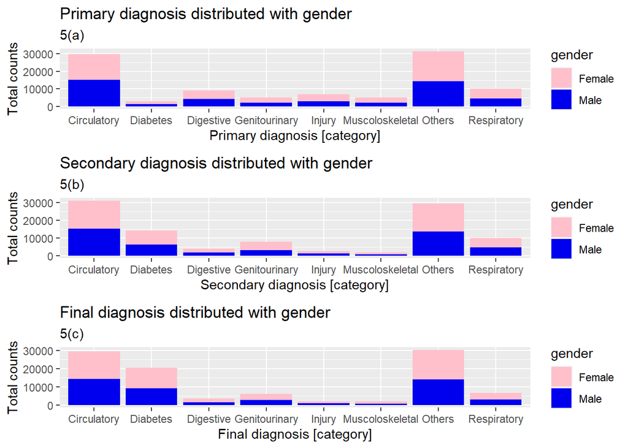

Looking at figure 5, we can see the results of the revaluation of attributes diag_1, diag_2, and diag_3. These attributes depict the primary, secondary, and final diagnosis of a patient, respectively. Interestingly, the difference between the figures is the increase in the number of diabetes diagnoses. Due to not testing diabetes on the initial hospitalization, readmission rates increase as a patient’s primary diagnosis is not sustainable. The data classification now shows a clearer picture and would undoubtedly be of fair use in the final dataset. The original authors did not keep diag_2 and diag_3, as it would make records too complex to achieve their goals. Removal of these two attributes is still up for discussion, but the analysis does not give - for now - a clear indication for potential removal.

In the next section, we look at attribute medical_specialty and decide whether it is useful enough - considering the number of missing values - to be a candidate for the final dataset. We construct multiple plots that zoom in on the categories and valuations of this attribute.

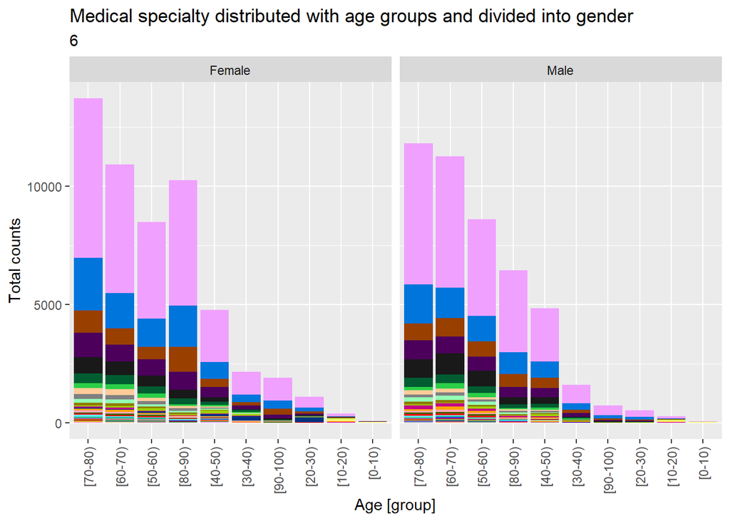

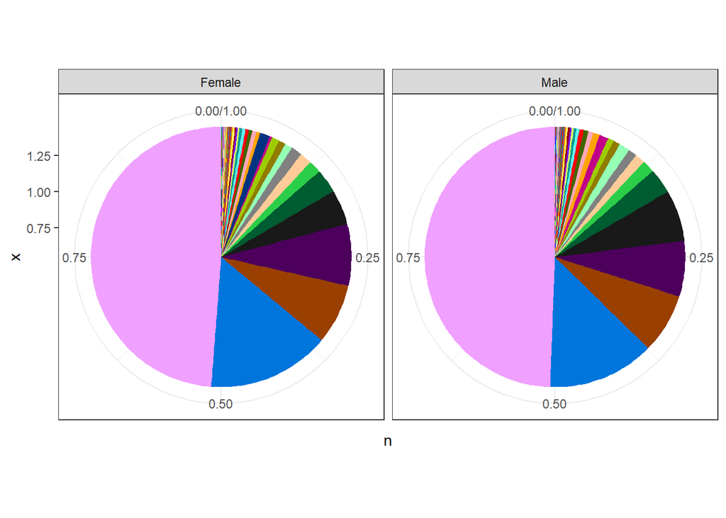

Looking at both figures 6 and 7, we observe a large amount of valuation between all demographic attributes used. Depicted in purple are the missing values, as already established, make-up almost 50 percent of total records. Medical specialty is different from, for example, admission_id, where we could shrink the attribute to a better format. This is an alternative to this attribute. We are considering this with the fact that medical specialty does not give better information than any diagnosis attribute, which also gives, maybe even more useful, guidance about an encounter’s medical history. At this stage, removal of this attribute could not be of lethal harm.

For our final categorical attribute, and one of the most influential -according to the original authors- we will discuss readmitted. Readmitted is an attribute with three different valuations: ‘<30’ for readmission within 30 days after release, ‘>30’ for readmission after 30 days release, and ‘NO’ for no readmission.

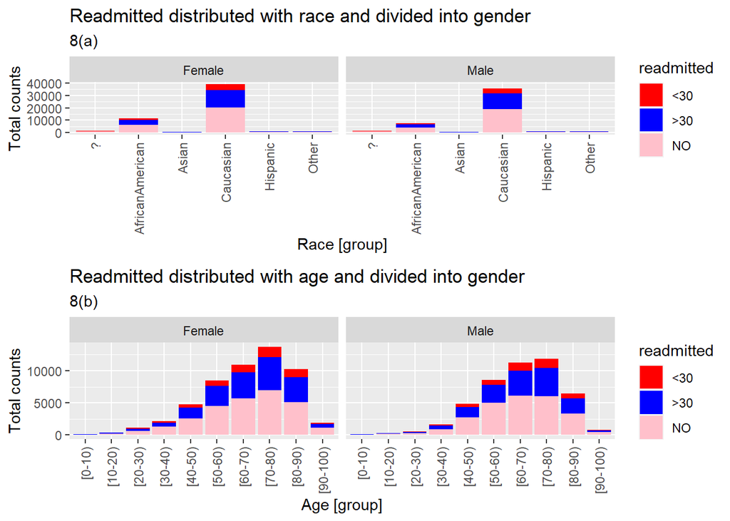

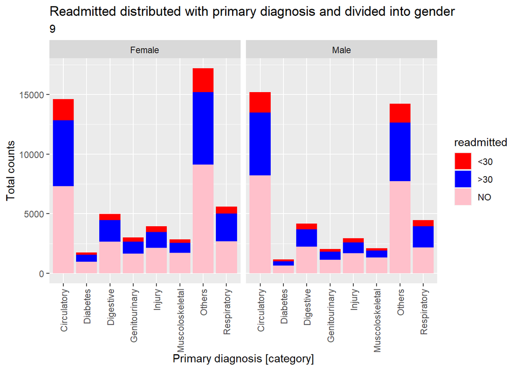

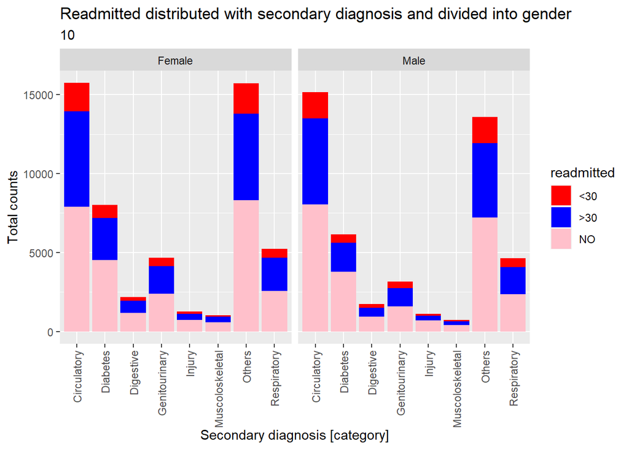

We observe the results of analyzing the readmitted attribute. We looked at readmitted with different demographics (gender, age, and race) and two of the three diagnosis attributes. Figure 8a shows that the Caucasian race has the most readmission rates in both genders. Observations made in figure 8b depict that as age increases, readmission rates also increase for females and males. This makes sense as immunity decreases with age, and the chance of recovery diminishes. Readmission rates decrease after the age of 80. The reasoning behind this might be death or transferring to a hospice or other facility.

Comparing the results in figures 9 and 10, we see a familiar trend: the increase of diabetes diagnoses between the primary and secondary diagnoses. This typically means that patients admitted were diagnosed differently, and over time, are getting a new diabetes diagnosis much quicker.

Seeing as we have multiple diagnosis categories but are somewhat interested in diabetes only, we can alter these attributes to have only two valuations (‘diabetes’ and ‘other’). However, doing this can affect later analysis as we remove potentially valuable information.

## Distribution - numeric attributes

We discussed many categorical data attributes, now turn to our few numeric data. It is important to have a good distribution between numeric data. If the range of distribution is too large, then normalization is necessary. We construct multiple histograms, which we get through the histogram.plotter() function.

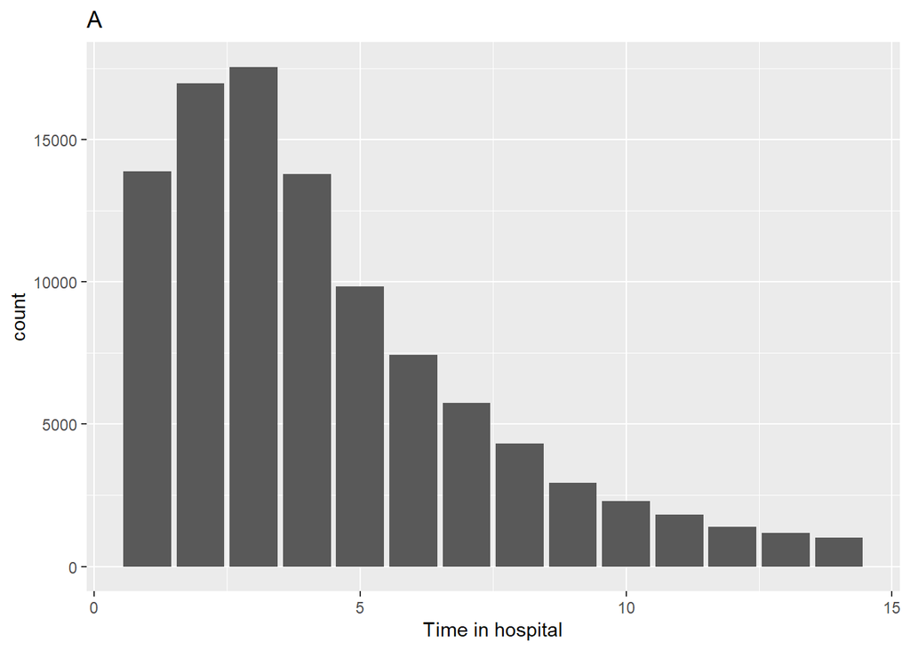

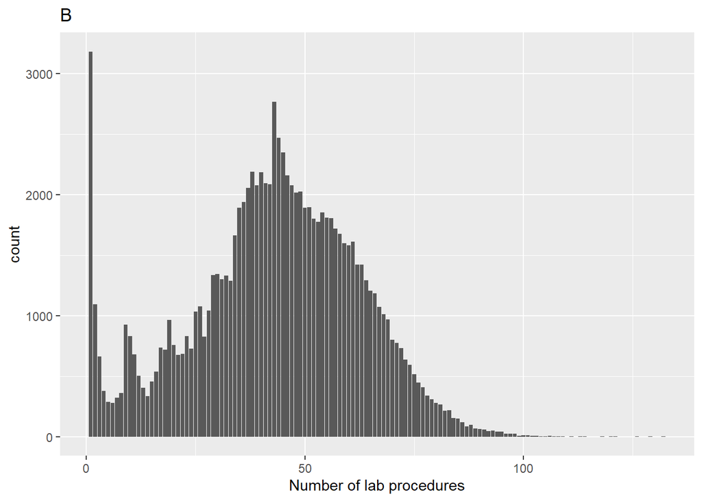

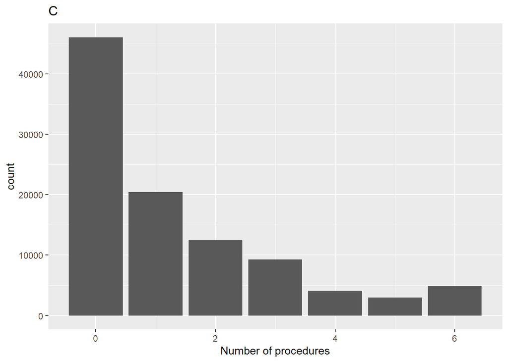

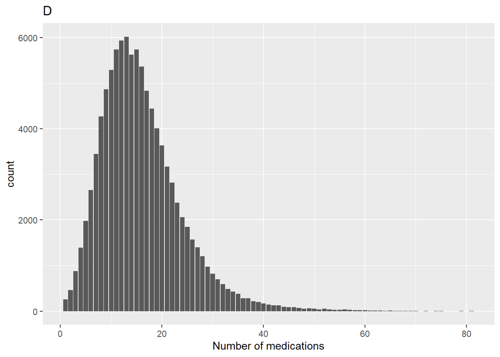

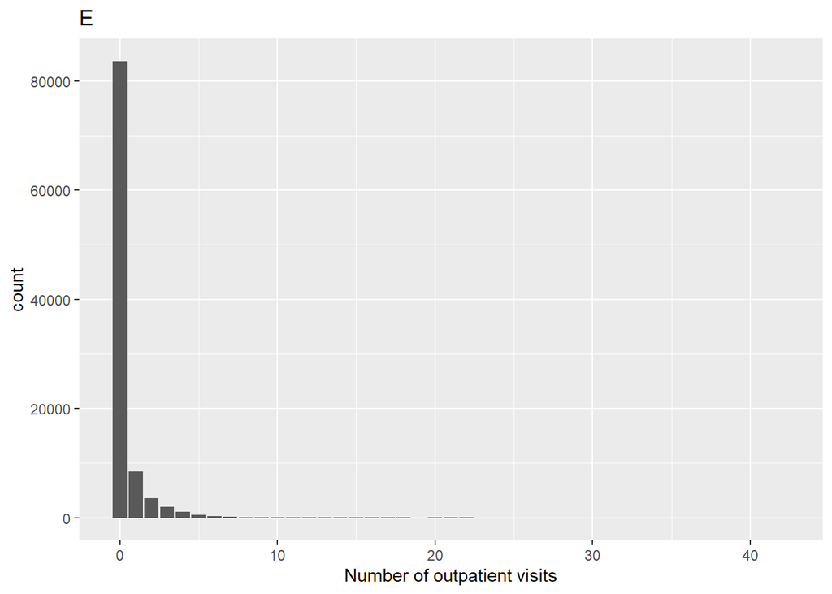

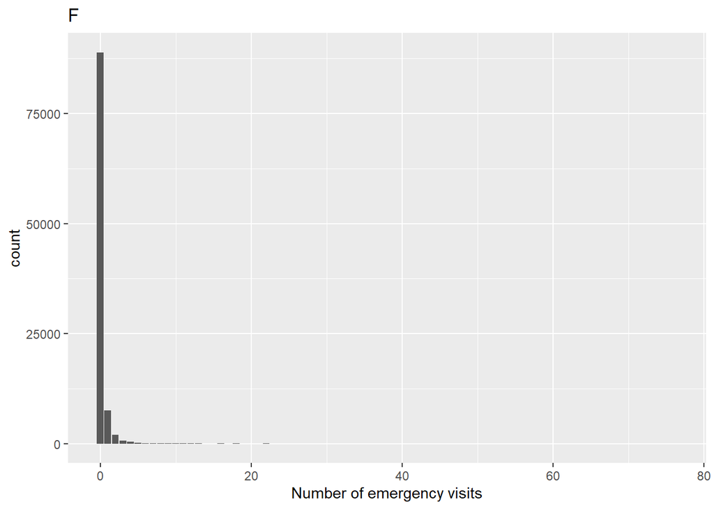

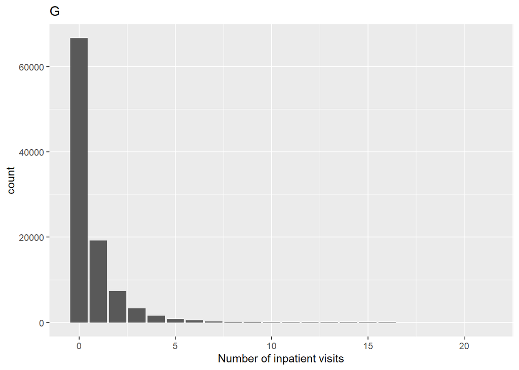

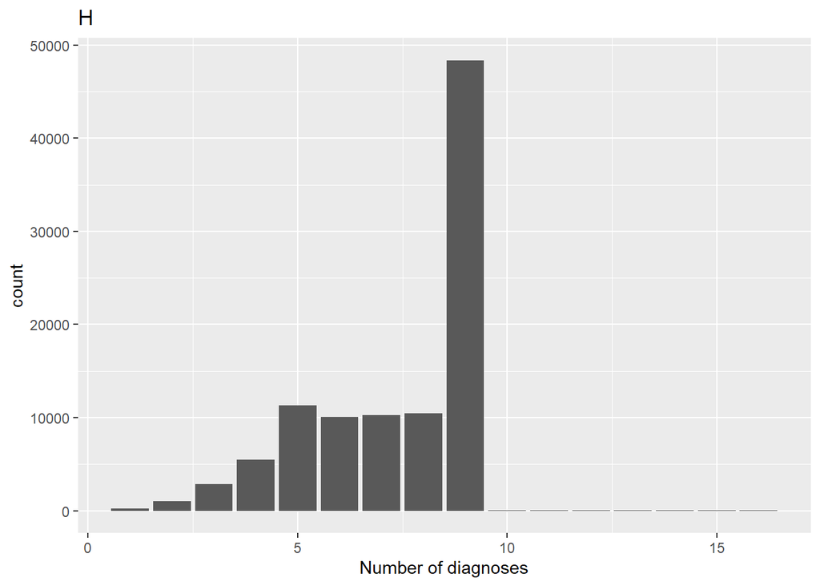

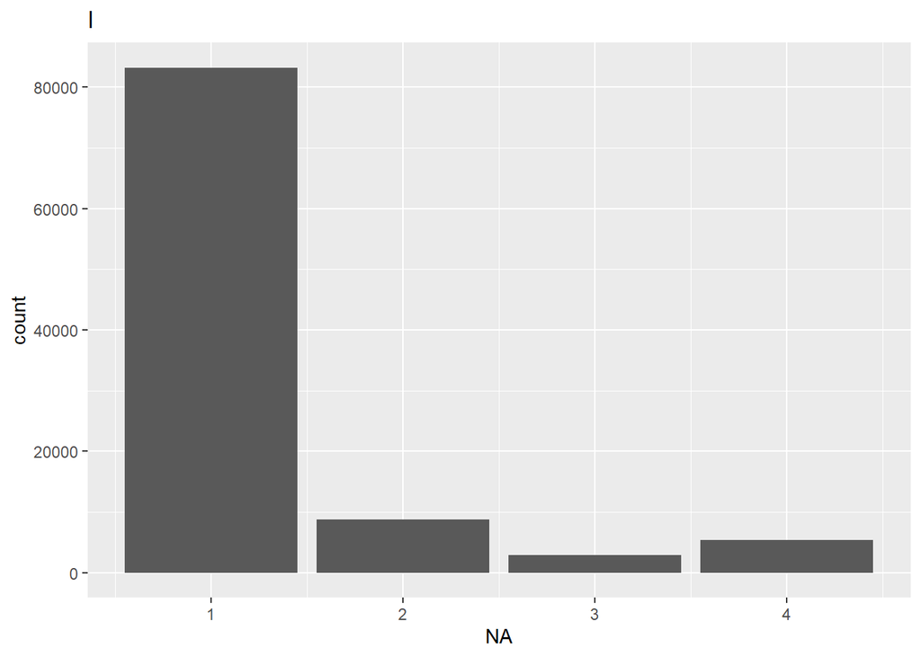

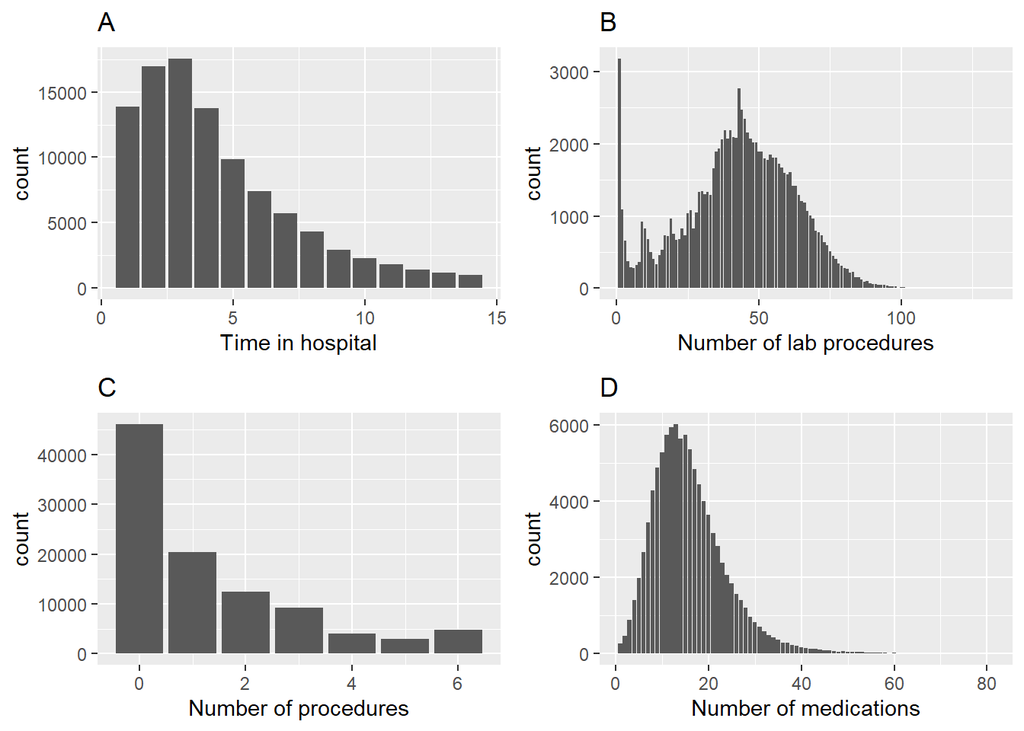

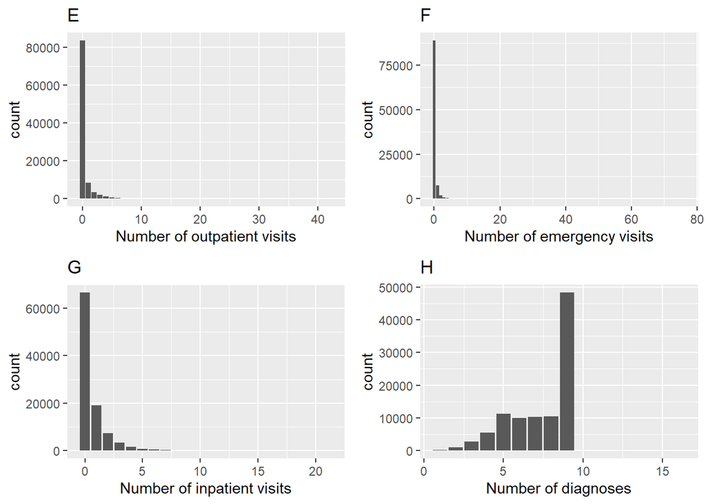

Looking at the results, depicted in figures 11 and 12, shows that not all of the attributes are evenly distributed. Normalization might be necessary to correct the distributions of namely B, which makes a couple of weird spikes, E, F, and G, which are all -but B- number of visits of an encounter. We might want to introduce a new attribute, total_visits, which accounts for all visits made by one encounter. The method of normalization is still up for debate.

## Correlation - numeric attributes

To discover any correlation between the numeric data in our dataset, we constructed a heatmap, which is depicted below. We discuss a possible correlation between age and time spent in the hospital and the potential relationship between the num_lab_procedures and num_medications.

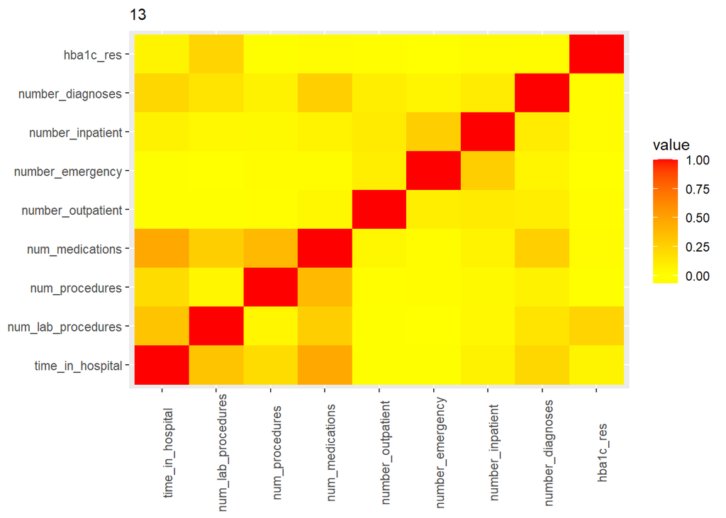

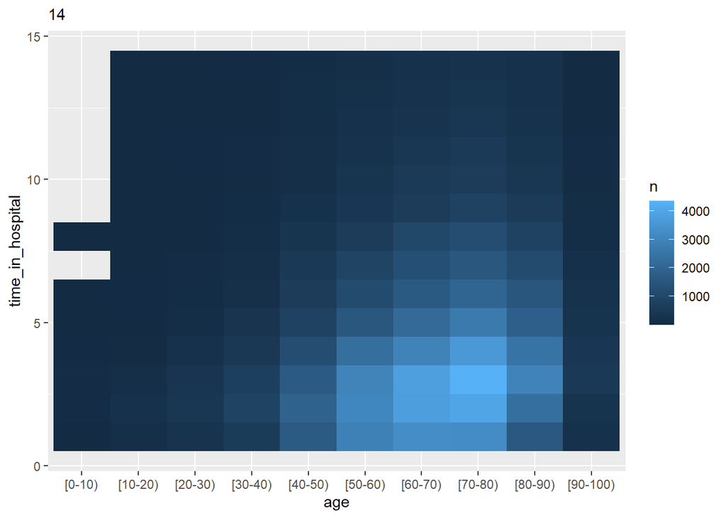

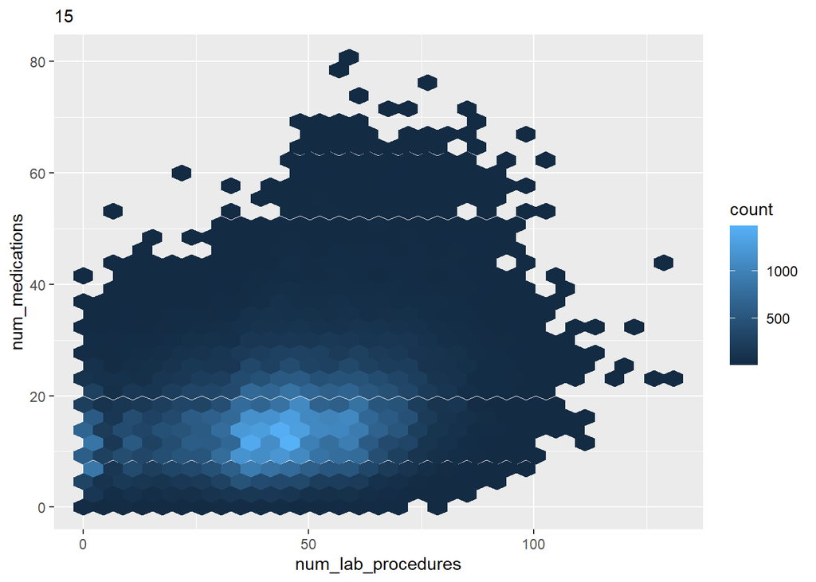

# Week 3: A Clean Dataset